# Visualization

## Outline

- Traditional Static Plots
  - Base R plotting
  - ggplot2
- Newer approaches
  - shiny, ggvis, htmlwidgets

## Traditional Static Plots

## Traditional Static Plotting

Never forget that Base R has a lot of visualization capabilities that can produce high quality graphs.

For many quick peeks, it's still often useful.

```r
x = rnorm(100)
y = 2*x^2 + rnorm(100)
```

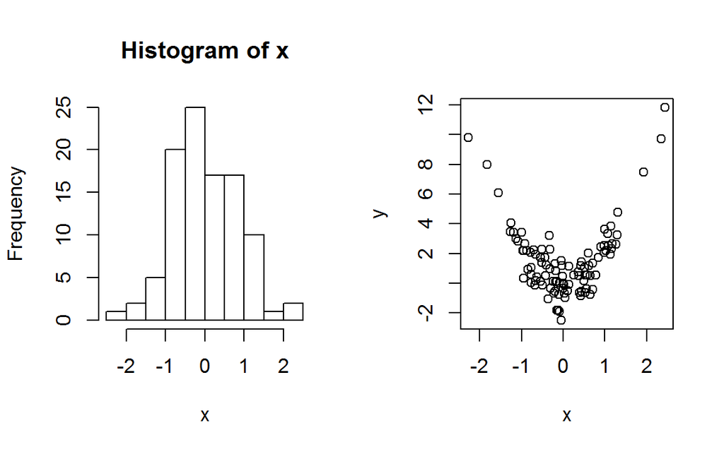

## Traditional Static Plotting

Unfortunately base R plots are not too impressive looking, as the defaults are generally poor (my opinion).

Many packages or other base R functions serve a particular purpose.

- heatmaps, dendrograms, diagnostics, correlation plots etc.

In addition, a widely used static plotting package is ggplot2

## ggplot2

ggplot2 is based on the 'Grammar of Graphics' and takes on a layered approach to building visualizations, using a technique similar to the piping we showed earlier.

It primarily works on dataframes.

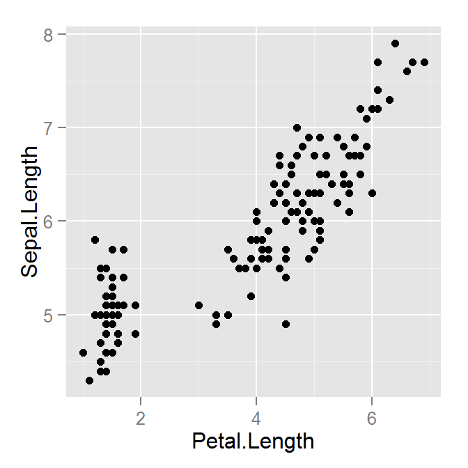

```r
library(ggplot2)

ggplot(aes(x=Petal.Length, y=Sepal.Length), data=iris) +
  geom_point()
```

## ggplot2

ggplot2 works on certain 'aesthetics', which are typically variables that take on different values, with 'geoms', things like points, lines, densities etc.

Let's add more.

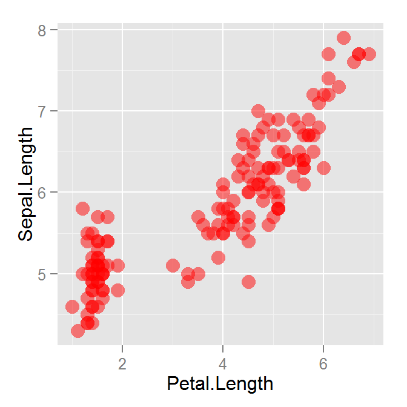

```r
ggplot(aes(x=Petal.Length, y=Sepal.Length), data=iris) +
  geom_point(color='red', size=4, alpha=.5)  # not within aesthetic function
```

## ggplot2

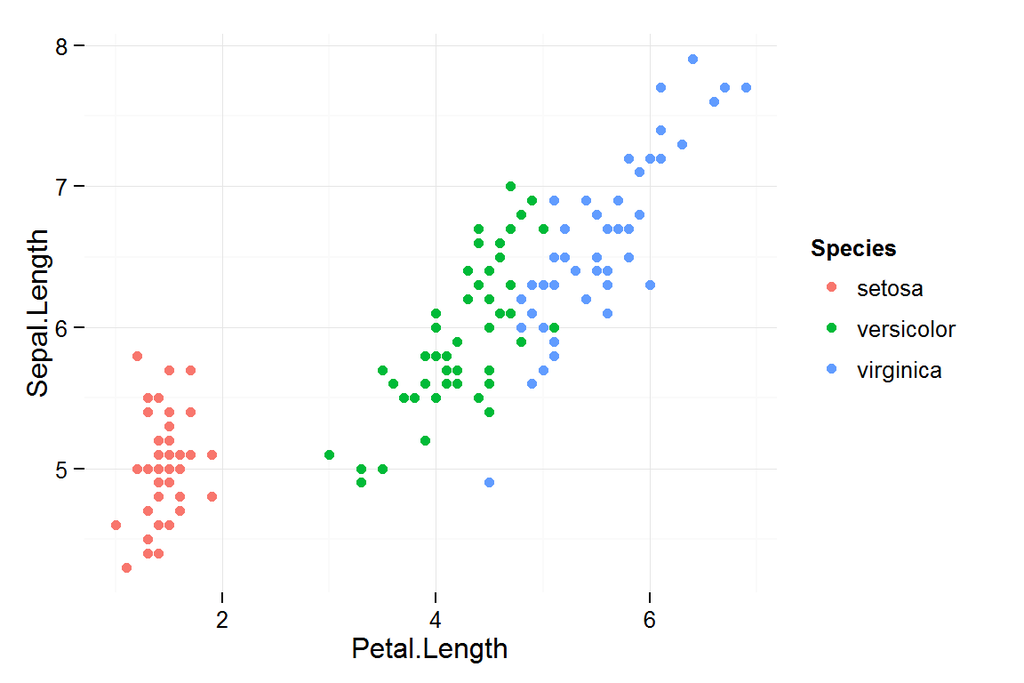

```r
ggplot(aes(x=Petal.Length, y=Sepal.Length), data=iris) +
  geom_point(aes(color=Species)) +
  theme_minimal()
```

## You try

Install ggplot2 if you haven't.

Change the aesthetics in the first line to look at Widths instead of Lengths.

Delete the interior portion of geom_point (i.e. it should look like geom_point()).

Add the following lines after the geom, keep the theme at the end if you want.

```r
  geom_smooth() +
  facet_wrap(~Species) +
```

If you like, use facet_grid rather than wrap.

## Newer approaches

ggplot2 was and still is an awesome tool and still very useful for standard static plots.

- And has continued to develop even as the creator has moved on

However, ggvis, its successor, enables interactivity and is more web-oriented.

Furthermore there is a growing number of packages put out by Rstudio and others that embrace modern methods of visual display.

## ggvis

The following shows how to do one of the previous plots with ggvis. Go ahead and put it into your script.

```r
library(ggvis)
ggvis(x=~Petal.Length, y=~Sepal.Length, data=iris) %>%
  layer_points(fill=~Species, fillOpacity:=.75)
```

## ggvis

As before, we'll build up from the above.

Try to add layer_smooths to the code, with an argument se=TRUE.

```r
ggvis(x=~Petal.Length, y=~Sepal.Length, data=iris) %>%
  layer_points(fill=~Species, fillOpacity:=.75)
```

## Going further

Search htmlwidgets showcase

- http://www.htmlwidgets.org/showcase_leaflet.html
- All of these are geared toward making interactive graphics as easy to procure as the normal ones.
- We demonstrated leaflet before

Shiny

- http://shiny.rstudio.com/gallery/
- We could have spent all of today on shiny.

My own (with Josh's assistance) demo using these tools.

- https://micl.shinyapps.io/texEx/texEx.Rmd

## Things to think about with visualization

Cleaner is almost always better

- avoid things like unnecessary grid lines, backgrounds etc.

Go beyond bivariate

- There is practically never a good reason for bar plot or similarly simple visuals that can be explained in a single sentence.
- God help you if you come to our office wanting a pie chart.

Think interactively

Color is required, not 'extra'

- But ~10% of the population has some form of color blindness.

## Exercise

We'll use the state.x77 data set

Your first step will be to convert it from a matrix to a dataframe, using the dataframe argument on the object.

The x and y axes will be Income and Life Expectancy.

Choose two other variables for two of color, size, or transparency. - transparency takes on values from 0 (invisible) to 1.

## Exercise

Using ggplot2, the basic approach is:

```r
ggplot2(aes(?), data=?) +
  geom_?()
```

Remember that things that can change value go in the aesthetic part.

The key arguments are x, y, size, color, and alpha.

Using ggvis, the basic approach is:

```r
data %>%
  ggvis(x=~?, y=~?) %>%
  layer_?(?)
```

Things that can change value are noted with =~

Other values of interest :=

The key arguments are x, y, size, fill, and fillOpacity.